# **Problem chińskiego listonosza**

Weronika Karbownik 258085

```python
# Biblioteki
from PIL import Image
import networkx as nx
import matplotlib.pyplot as plt
import itertools
import numpy as np
from scipy.optimize import linear_sum_assignment
```

## Autor koncepcji problemu chińskiego listonosza

Problem został pierwszy raz sformułowany przez chińskiego matematyka Meigu Guana (Mei-Ko Kwan) w 1960 roku, chociaż na język angielski został przetłumaczony dopiero dwa lata później.

```
(np.float64(-0.5), np.float64(919.5), np.float64(568.5), np.float64(-0.5))
```

[figure not shown]

```python
img = Image.open('matematyk_91.jpg')
plt.figure(figsize=(8, 8))
plt.imshow(img)
plt.axis('off')
```

## Biedny pracujący listonosz - historia prawdziwa

> „Listonosz, roznosząc listy, musi przejść przez wszystkie ulice w swojej dzielnicy co najmniej jeden raz i wrócić na pocztę. Ponieważ jest człowiekiem leniwym (nie odnosi się to do pozostałych listonoszy, tylko do tego konkretnego), chciałby mieć jak najkrótszą do przejścia trasę. Znalezienie takiej trasy jest problemem, który nazwano problemem chińskiego listonosza."

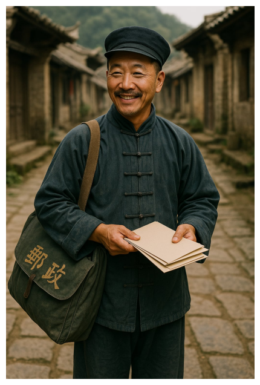

```python
img = Image.open('Chinski_listonosz.png')
plt.figure(figsize=(8, 8))

plt.imshow(img)
plt.axis('off')
plt.show()
```

## Problem matematyczny:

Problem biednego listonosza można przedstawić jako spójny, nieskierowany, ważony graf, w którym:

- wierzchołki reprezentują skrzyżowania,
- krawędzie odpowiadają ulicom, którymi listonosz musi przejść przynajmniej raz,
- wagi krawędzi to długości tych ulic.

Poczta jest wierzchołkiem startowym i końcowym (zakładamy, że poczta zawsze znajduje się na skrzyżowaniu).

Celem jest znalezienie cyklu zaczynającego się i kończącego na poczcie, który przechodzi przez wszystkie krawędzie i możliwie jak najmniejszą sumę długości.

## Algorytmy i twierdzenia

Twierdzenie:

W grafie można znaleźć cykl Eulera wtedy i tylko wtedy, gdy graf jest spójny i każdy jego wierzchołek ma parzysty stopień.

Algorytm Dijkstry - służy do znajdowania najkrótszych ścieżek z wybranego wierzchołka do pozostałych wierzchołków w grafie o nieujemnych wagach krawędzi.

Algorytm Węgierski - służy do wyznaczenia optymalnego (minimalnego kosztowo) sposobu sparowania wierzchołków o nieparzystym stopniu. Po więcej szczegółów zapraszam serdecznie do projektu Pana Krzysztowa Szewczyka

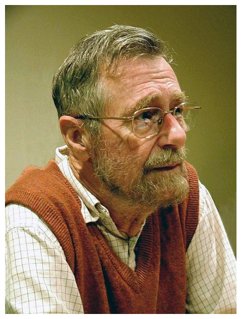

```python
img = Image.open('Dijkstra_orginal.jpg')
plt.figure(figsize=(8, 8))

plt.imshow(img)
plt.axis('off')
plt.show()
```

## Problem Chińskiego Listonosza - kod

```python
class Problem_Chinskiego_Listonosza:


    def __init__(self, graf: nx.Graph):
        self.graf = graf.copy()# Kopia grafu danego przez użytkownika
        for u, v, dane in self.graf.edges(data=True):# Przegląda wszystkie krawędzie.
            if 'weight' not in dane: # Jeśli krawędź nie ma przypisanej wagi, ustawia ją na `1`.
                dane['weight'] = 1
        # Sumujemy wagi wszystkich krawędzi. Jeśli graf, będzie eulorowski, to będzie to nasz wynik.
        self.suma_krawedzi = sum(dane['weight'] for _, _, dane in self.graf.edges(data=True))


    def Rysunek(self):
      # Funkcja umożliwiająca rysowanie grafów
        pozycje = nx.spring_layout(self.graf, seed=42)
        nx.draw(self.graf, pozycje,
                with_labels=True,
                node_color='lightblue',
                node_size=800,
                edge_color='mediumpurple')

        etykiety_krawedzi = nx.get_edge_attributes(self.graf, 'weight')
        nx.draw_networkx_edge_labels(self.graf, pozycje, edge_labels=etykiety_krawedzi)
        plt.show()


    def Czy_spojny(self):
        return nx.is_connected(self.graf)


    def Czy_eulerowski(self):
        return nx.is_eulerian(self.graf)


    def Nieparzyste_wierzcholki(self):
        # Zwraca listę wierzchołków, które mają nieparzysty stopień.
        # To one przeszkadzają w tym aby graf był grafem Eulera
        return [w for w in self.graf.nodes if self.graf.degree[w] % 2 == 1]


    def Dijkstra(self, wierzcholki):
        # Funkcja oblicza najkrótsze odległości miedzy każdą parą wierzchołków o nieparzystym stopniu przy użyciu algorytmu Dijkstry.
        odleglosci_par = {}
        for u, v in itertools.combinations(wierzcholki, 2):
            dlugosc = nx.dijkstra_path_length(self.graf, u, v, weight='weight')
            odleglosci_par[(u, v)] = dlugosc
        return odleglosci_par


    def Macierz_odleglosci(self, nieparzyste, odleglosci_par):
        # Tworzymy macierz kosztów z rozmiarami odpowiadającymi liczbie wierzchołków o nieparzystym stopniu.
        n = len(nieparzyste)
        macierz_kosztow = np.full((n, n), np.inf)
        # Następnie uzupełniamy macierz kosztów na podstawie obliczonych najkrótszych odległości
        for i in range(n):
            for j in range(n):
                if i != j:
                    u, v = nieparzyste[i], nieparzyste[j]
                    macierz_kosztow[i][j] = odleglosci_par.get((u, v), odleglosci_par.get((v, u), np.inf))
        return macierz_kosztow


    def Rozwiazanie(self, poczta ='A'):
      # Funkcja rozwiązania problemu listonosza

      if poczta not in self.graf.nodes: # Sprawdzamy czy poczta istnieje
        print(f"Wierzchołek '{poczta}' nie istnieje w grafie")
        return None

      if not self.Czy_spojny(): # Sprawdzamy czy graf jest spójny
          print("Graf NIE jest spójny — nie można rozwiązać problemu chińskiego listonosza.")
          return None

      if self.Czy_eulerowski(): # Sprawdzamy czy graf jest eurelowski
          print("Graf jest eulerowski.")
          return self.suma_krawedzi

      nieparzyste = self.Nieparzyste_wierzcholki()
      odleglosci_par = self.Dijkstra(nieparzyste)
      macierz_kosztow = self.Macierz_odleglosci(nieparzyste, odleglosci_par)
      # Algorytm węgierski - które wierzchołki należy połączyć w pary, żeby suma odległości między nimi była najmniejsza.
      wiersze, kolumny = linear_sum_assignment(macierz_kosztow)
      # Przetwarzamy wynik algorytmu węgierskiego.
      dopasowania_ostateczne = [] # Pary wierzchołków ostateczne (Tworzymy listę dopasowania_ostateczne, która zawiera indeksy wierzchołków, które trzeba połączyć)

      for i, j in zip(wiersze, kolumny):
          if i < j: # Warunek aby pary się nie powtarzały
              dopasowania_ostateczne.append((i, j))

      # Dla każdej pary wierzchołków, znajdź ścieżkę Dijkstry i dodaj ją do grafu
      for i, j in dopasowania_ostateczne:
          u, v = nieparzyste[i], nieparzyste[j]
          # Znajdź najkrótszą ścieżkę między parą u–v
          sciezka = nx.dijkstra_path(self.graf, u, v, weight='weight')
          # Przetwarzamy ścieżkę krok po kroku, dodając zduplikowane krawędzie
          for a, b in zip(sciezka[:-1], sciezka[1:]):
              if self.graf.has_edge(a, b):
              # Jeśli krawędź istnieje, oznaczamy ją jako zduplikowaną
                  self.graf[a][b]['duplicate'] = self.graf[a][b].get('duplicate', 0) + 1

      calkowity_koszt = 0 # Uwzględniamy zduplikowane krawędzie
      for _, _, dane in self.graf.edges(data=True): # Pętla przechodząca po wszystkich krawędziach grafu
          # 'duplicate' będzie zawierał ile razy trzeba było dodać dodatkową krawędź.
          liczba = 1 + dane.get('duplicate', 0) # Każda krawędź przechodzona przynajmniej raz (1)
          calkowity_koszt += dane['weight'] * liczba # Waga krawędzi × liczba przejść
      return calkowity_koszt


    def Trasa_listonosza(self, poczta='A'):

      # Sprawdzamy czy poczta istnieje
      if poczta not in self.graf.nodes:
        print(f"Wierzchołek '{poczta}' nie istnieje w grafie.")
        return None

      # Sprawdzamy czy graf jest spójny
      if not self.Czy_spojny():
        print("Graf NIE jest spójny — nie można rozwiązać problemu chińskiego listonosza.")
        return None

      # Sprawdzamy czy graf jest eurelowski
      if self.Czy_eulerowski():
        cykl = list(nx.eulerian_circuit(self.graf, source=poczta))
        print("Długość najkrótszej trasy:", self.suma_krawedzi)
        return cykl

      nieparzyste = self.Nieparzyste_wierzcholki()
      odleglosci_par = self.Dijkstra(nieparzyste)
      macierz_kosztow = self.Macierz_odleglosci(nieparzyste, odleglosci_par)

      wiersze, kolumny = linear_sum_assignment(macierz_kosztow)
      dopasowania_ostateczne = []
      # Tworzymy MultiGraph w celu wyznaczenia ścieżki
      X = nx.MultiGraph(self.graf)

    # Dobieramy nieparzyste wierzchołki w pary
      for i, j in zip(wiersze, kolumny):
        if i < j:# Warunek aby pary się nie powtarzały
            dopasowania_ostateczne.append((i, j))


    # Dodajemy ścieżki Dijkstry do MultiGraph
      for i, j in dopasowania_ostateczne:
        u, v = nieparzyste[i], nieparzyste[j]
        # Wyznaczamy najkrótszą ścieżkę pomiędzy u i v
        sciezka = nx.dijkstra_path(self.graf, u, v, weight='weight')
        print(f"\nDopasowanie: {u} <--> {v}") # Wyświetlamy najkrótszą ścieżkę
        print(f"Ścieżka pomiędzy {u} a {v}: {sciezka}")

        # Dodajemy każdą krawędź ze ścieżki do grafu X (jako nową krawędź w MultiGraph)
        for a, b in zip(sciezka[:-1], sciezka[1:]):
            waga = self.graf[a][b]['weight']
            X.add_edge(a, b, weight=waga)
      cykl = list(nx.eulerian_circuit(X, source=poczta))
      suma_wag = sum(d['weight'] for u, v, d in X.edges(data=True))
      print("Długość najkrótszej trasy:", suma_wag)
      return cykl
```

## Przykłady

### Graf - działanie klasy krok po kroku

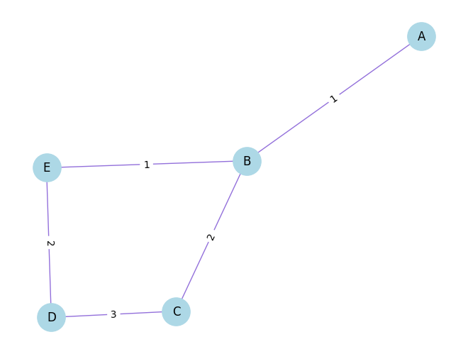

```python
G_0 = nx.Graph()
G_0.add_weighted_edges_from([
    ('A', 'B', 1),
    ('B', 'C', 2),
    ('D', 'C', 3),
    ('D', 'E', 2),
    ('E', 'B', 1)
])
listonosz_0= Problem_Chinskiego_Listonosza(G_0)
listonosz_0.Rysunek()
```

```python
print("Czy graf spójny?", listonosz_0.Czy_spojny())
print("Czy graf eulerowski?", listonosz_0.Czy_eulerowski())
```

```
Czy graf spójny? True
Czy graf eulerowski? False
```

```python
nieparzyste = listonosz_0.Nieparzyste_wierzcholki()
print("Wierzchołki o nieparzystym stopniu:", nieparzyste)
```

```
Wierzchołki o nieparzystym stopniu: ['A', 'B']
```

```python
odleglosci_par = listonosz_0.Dijkstra(nieparzyste)
print("Najkrótsza odległości par:", odleglosci_par)
```

```
Najkrótsza odległości par: {('A', 'B'): 1}
```

```python
macierz = listonosz_0.Macierz_odleglosci(nieparzyste, odleglosci_par)
print("Macierz odległości:\n", macierz)
```

```
Macierz odległości:
 [[inf  1.]
 [ 1. inf]]
```

```python
dlugosc_trasy = listonosz_0.Rozwiazanie()
print(f"Długość najkrótszej trasy: {dlugosc_trasy}")
```

```
Długość najkrótszej trasy: 10
```

```python
trasa = listonosz_0.Trasa_listonosza()
print(f"Trasa biednego listonosza: {trasa}")
```

```
Dopasowanie: A <--> B
Ścieżka pomiędzy A a B: ['A', 'B']
Długość najkrótszej trasy: 10
Trasa biednego listonosza: [('A', 'B'), ('B', 'E'), ('E', 'D'), ('D', 'C'), ('C', 'B'), ('B', 'A')]
```

### Graf niespójny

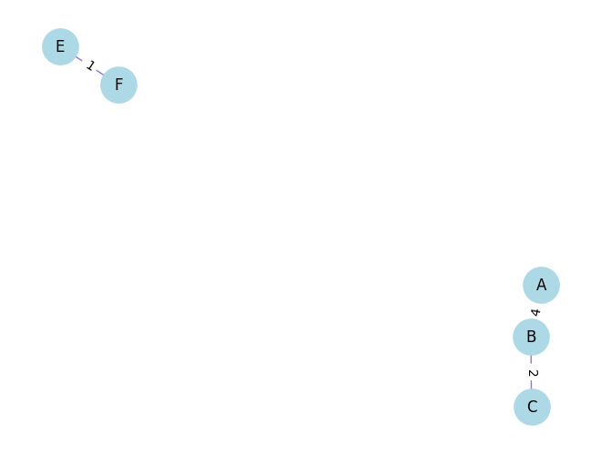

```python
G_1 = nx.Graph()
G_1.add_weighted_edges_from([
    ('A', 'B', 4),
    ('B', 'C', 2),
    ('E', 'F', 1)
])
listonosz_1= Problem_Chinskiego_Listonosza(G_1)
listonosz_1.Rysunek()
```

```python
listonosz_1.Trasa_listonosza()
```

```
Graf NIE jest spójny — nie można rozwiązać problemu chińskiego listonosza.
```

### Graf Eulera

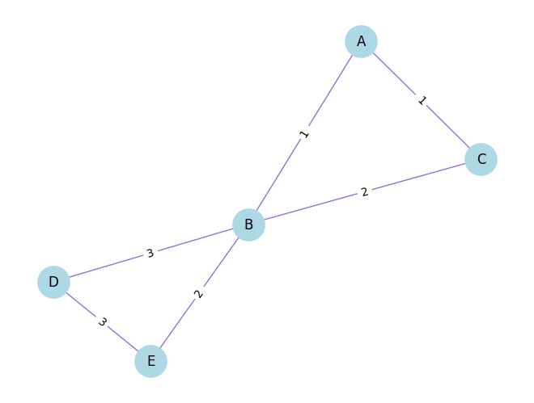

```python
G_2 = nx.Graph()
G_2.add_weighted_edges_from([
    ('A', 'B', 1),
    ('B', 'E', 2),
    ('E', 'D', 3),
    ('D', 'B', 3),
    ('B', 'C', 2),
    ('C', 'A', 1)
])
listonosz_2= Problem_Chinskiego_Listonosza(G_2)
listonosz_2.Rysunek()
```

```python
dlugosc_trasy_2 = listonosz_2.Rozwiazanie()
listonosz_2.Trasa_listonosza()
```

```
Graf jest eulerowski.
Długość najkrótszej trasy: 12
```

```
[('A', 'C'), ('C', 'B'), ('B', 'D'), ('D', 'E'), ('E', 'B'), ('B', 'A')]
```

### Grafy Testy

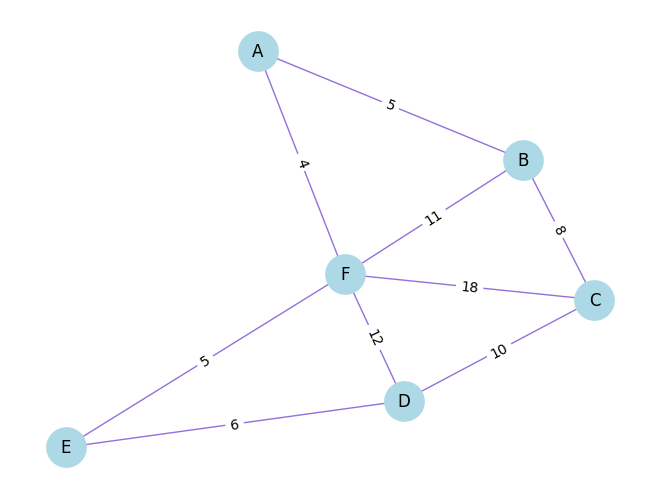

```
Dopasowanie: F <--> B
Ścieżka pomiędzy F a B: ['F', 'A', 'B']

Dopasowanie: D <--> C
Ścieżka pomiędzy D a C: ['D', 'C']
Długość najkrótszej trasy: 98
```

```
[('A', 'B'),
 ('B', 'C'),
 ('C', 'D'),
 ('D', 'C'),
 ('C', 'F'),
 ('F', 'D'),
 ('D', 'E'),
 ('E', 'F'),
 ('F', 'B'),
 ('B', 'A'),
 ('A', 'F'),
 ('F', 'A')]
```

```python
G_3 = nx.Graph()
G_3.add_weighted_edges_from([
        ('A', 'F', 4),
        ('F', 'E', 5),
        ('E', 'D', 6),
        ('D', 'C', 10),
        ('C', 'B', 8),
        ('B', 'A', 5),
        ('B', 'F', 11),
        ('F', 'C', 18),
        ('F', 'D', 12)
    ])
listonosz_3= Problem_Chinskiego_Listonosza(G_3)
listonosz_3.Rysunek()
listonosz_3.Trasa_listonosza()
```

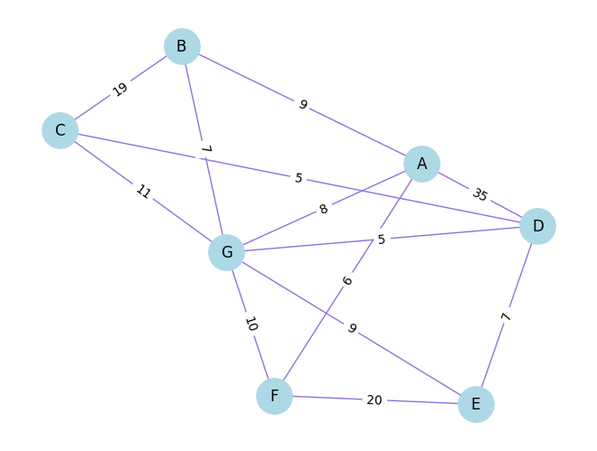

```
Dopasowanie: F <--> B
Ścieżka pomiędzy F a B: ['F', 'A', 'B']

Dopasowanie: C <--> E
Ścieżka pomiędzy C a E: ['C', 'D', 'E']
Długość najkrótszej trasy: 178
```

```
[('A', 'B'),
 ('B', 'C'),
 ('C', 'D'),
 ('D', 'C'),
 ('C', 'G'),
 ('G', 'E'),
 ('E', 'D'),
 ('D', 'E'),
 ('E', 'F'),
 ('F', 'G'),
 ('G', 'B'),
 ('B', 'A'),
 ('A', 'F'),
 ('F', 'A'),
 ('A', 'G'),
 ('G', 'D'),
 ('D', 'A')]
```

```python
G_4 = nx.Graph()
G_4.add_weighted_edges_from([
    ('A', 'D', 35),
    ('A', 'F', 6),
    ('A', 'G', 8),
    ('A', 'B', 9),
    ('B', 'C', 19),
    ('B', 'G', 7),
    ('G', 'C', 11),
    ('G', 'D', 5),
    ('G', 'E', 9),
    ('G', 'F', 10),
    ('F', 'E', 20),
    ('E', 'D', 7),
    ('D', 'C', 5)
])
listonosz_4= Problem_Chinskiego_Listonosza(G_4)
listonosz_4.Rysunek()
listonosz_4.Trasa_listonosza()
```

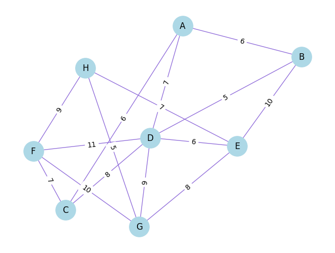

```
Dopasowanie: A <--> B
Ścieżka pomiędzy A a B: ['A', 'B']

Dopasowanie: C <--> H
Ścieżka pomiędzy C a H: ['C', 'F', 'H']
Długość najkrótszej trasy: 136
```

```
[('A', 'B'),
 ('B', 'D'),
 ('D', 'G'),
 ('G', 'E'),
 ('E', 'H'),
 ('H', 'G'),
 ('G', 'F'),
 ('F', 'H'),
 ('H', 'F'),
 ('F', 'C'),
 ('C', 'F'),
 ('F', 'D'),
 ('D', 'C'),
 ('C', 'A'),
 ('A', 'B'),
 ('B', 'E'),
 ('E', 'D'),
 ('D', 'A')]
```

```python
G_5 = nx.Graph()
G_5.add_weighted_edges_from([
    ('A', 'D', 7),
    ('A', 'C', 6),
    ('A', 'B', 6),
    ('C', 'F', 7),
    ('F', 'H', 9),
    ('H', 'E', 7),
    ('E', 'B', 10),
    ('E', 'D', 6),
    ('E', 'G', 8),
    ('H', 'G', 5),
    ('F', 'G', 10),
    ('F', 'D', 11),
    ('C', 'D', 8),
    ('B', 'D', 5),
    ('D', 'G', 9)

])
listonosz_5= Problem_Chinskiego_Listonosza(G_5)
listonosz_5.Rysunek()
listonosz_5.Trasa_listonosza()
```

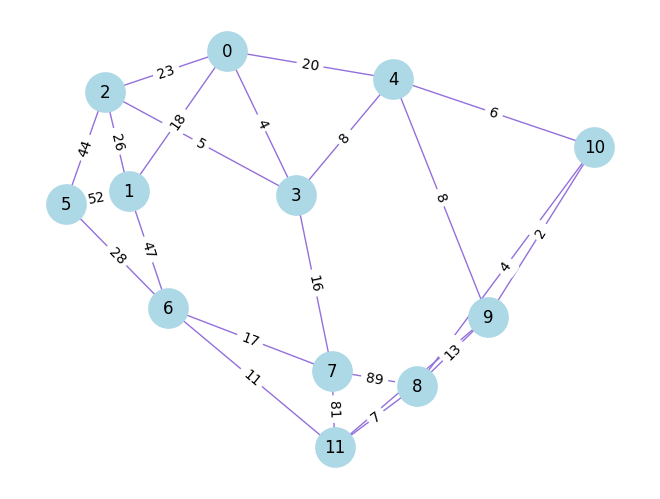

```
Dopasowanie: 5 <--> 10
Ścieżka pomiędzy 5 a 10: [5, 6, 11, 8, 10]
Długość najkrótszej trasy: 591
```

```
[(0, 4),
 (4, 10),
 (10, 8),
 (8, 11),
 (11, 8),
 (8, 10),
 (10, 9),
 (9, 11),
 (11, 6),
 (6, 11),
 (11, 7),
 (7, 8),
 (8, 9),
 (9, 4),
 (4, 3),
 (3, 7),
 (7, 6),
 (6, 5),
 (5, 6),
 (6, 1),
 (1, 5),
 (5, 2),
 (2, 3),
 (3, 0),
 (0, 2),
 (2, 1),
 (1, 0)]
```

```python
G_6 = nx.Graph()
G_6.add_weighted_edges_from([
    (0, 1, 18),
    (0, 2, 23),
    (0, 3, 4),
    (0, 4, 20),
    (1, 2, 26),
    (1, 5, 52),
    (1, 6, 47),
    (2, 3, 5),
    (2, 5, 44),
    (3, 4, 8),
    (3, 7, 16),
    (4, 9, 8),
    (4, 10, 6),
    (5, 6, 28),
    (6, 7, 17),
    (6, 11, 11),
    (7, 8, 89),
    (7, 11, 81),
    (8, 9, 13),
    (8, 10, 4),
    (8, 11, 7),
    (9, 10, 2),
    (9, 11, 12)
])
listonosz_6= Problem_Chinskiego_Listonosza(G_6)
listonosz_6.Rysunek()
listonosz_6.Trasa_listonosza(0)
```

## Bibliografia

- https://en.wikipedia.org/wiki/Meigu_Guan
- https://eduinf.waw.pl/inf/alg/001_search/0139.php (historyjka, przykład i zarys algorytmu)
- https://www.suffolkmaths.co.uk/pages/Maths%20Projects/Projects/Topology%20and%20Graph%20Theory/Chinese%20Postman%20Problem.pdf (grafy do testu)

# Dziękuję za uwagę !

```
(np.float64(-0.5), np.float64(1023.5), np.float64(1535.5), np.float64(-0.5))
```

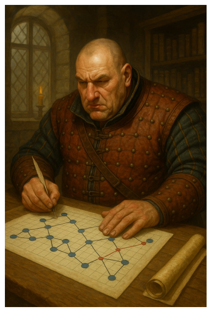

```python
img = Image.open('Szpieg_redani.png')
plt.figure(figsize=(8, 8))
plt.imshow(img)
plt.axis('off')
```